# Incarceration Report

Andrew Le

## Introduction

In light of recent events, there have been many reports and news articles highlighting the unfair treatment of minorities, black people specifically, by the police across the country. In this report, we utilize the data given to us by Vera which has combined many different data sets from government official bureaus, and has recorded the incarceration rates by race, region, state, etc. from 1970 all the way to 2018. With this data, we can draw conclusions about the unfair treatment and incarceration of minorities, with a focus on the black population, and the disproportionate incarceration rates in which the black population fall victim to. These values differ in various regions and races, as we will observe the US as a whole, and then break it down to a state level.

With all values averaged over a 50 year time period, in the US, black people make up **9.2%** of the total population, but make up **50.38 %** of the total incarcerated population. Compare these statistics to those of white people, they take up a majority of the population, with **49.35%** of the total population, and making up **56.27%** of the total incarcerated population. Even though the black population make up a fraction of the total population compared to white people, they are incarcerated on average, almost as equivalently to white people. This shows a disproportionate incarceration rate compared to the total population black people make up- leading to the conclusion that they are unfairly incarcerated and prosecuted. As we break this down further, the region in which black people take up the lowest amount in the total incarcerated population is on the West Coast, with **16.6%** of the total incarcerated population being black whilst taking up **3.98%** of the total population. As we move to the South, this is where the black incarcerated population percentage is the largest in the 4 regions, with **62.42%** of the total incarcerated population being black while making up **22.08%** of the total population in the South. As we can see, in the lowest and the highest region, the percentage in which black people are apart of the incarcerated population is extremely disproportionate to the total percentage of the total population that black people make up.

## Incarceration Population Rates Over Time

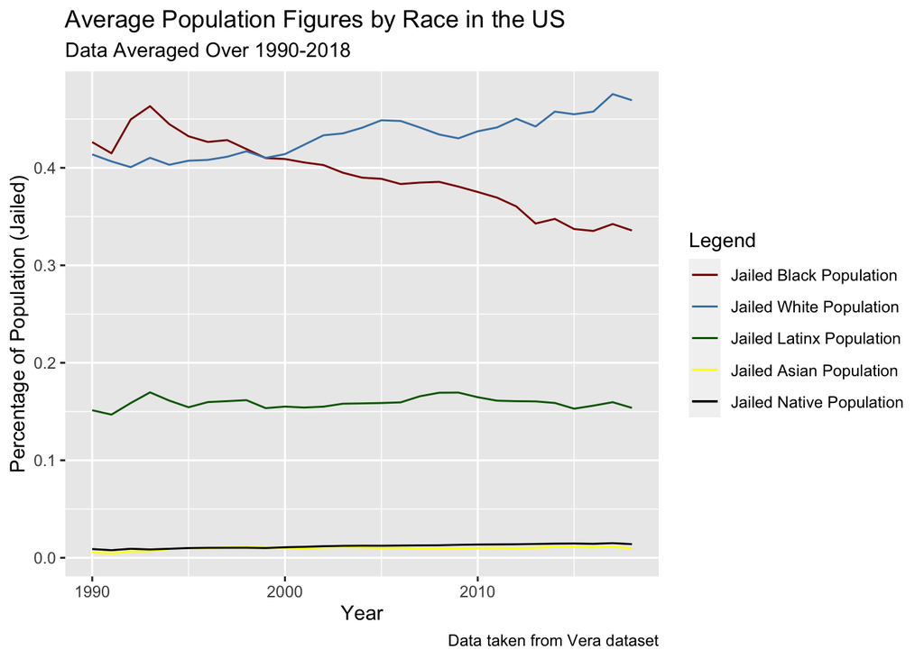

The graph above was chosen to comprehend the average incarceration rates by race of the US, and to highlight the discrepancies between races, with the black population being focused as the race that is disproportionately incarcerated amongst all the races. The graph was designed in a way in which the trend over time was easy to comprehend, and the values were averaged every year, from data from every region in the United States. We can see a slight decrease in which the black population make up the incarcerated population, and an increase in the white population. We also see a steady trend for the Latinx population in terms of incarceration population- with Asian Americans and Natives taking up the lowest percentage of the incarcerated population. With no real improvement in the Latinx population, we could make assumptions that although the percentage they take up is consistent, there has been no real change, and a lot of factors play a part of that. What is consistent in the graph is although as mentioned prior, the black population makes up a miniscule amount in the total population of the United States, they make up almost as much of the incarcerated population as the white population- whom take a majority share in the total population. This graph would then showcase a racial bias and prejudice towards the black population in terms of incarceration and would lead anyone who views this graph to make the assumption that based on the data- police incarcerate more of the black population than the white population, in terms of comparative total population size.

## Black Jailed Population compared to Total Black Population in the US

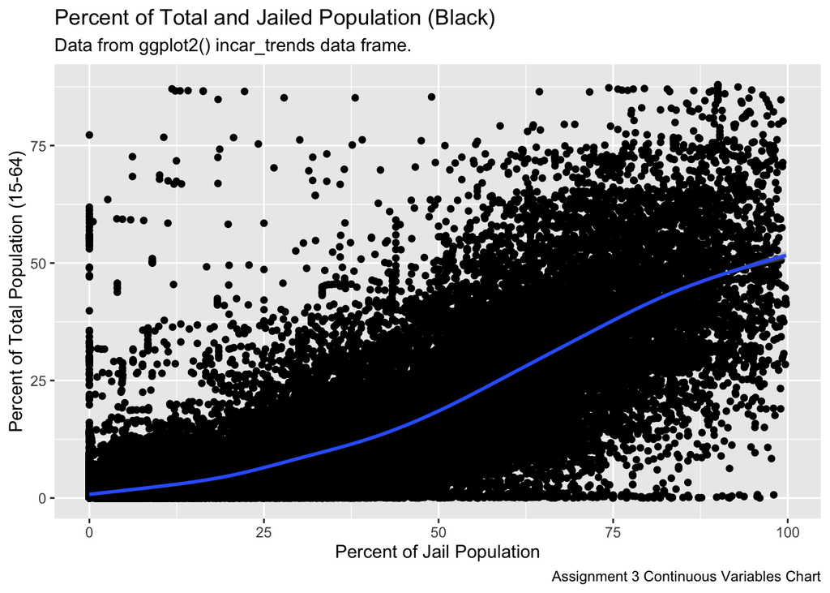

## Geographical Trends Related to Jailing of Black Population

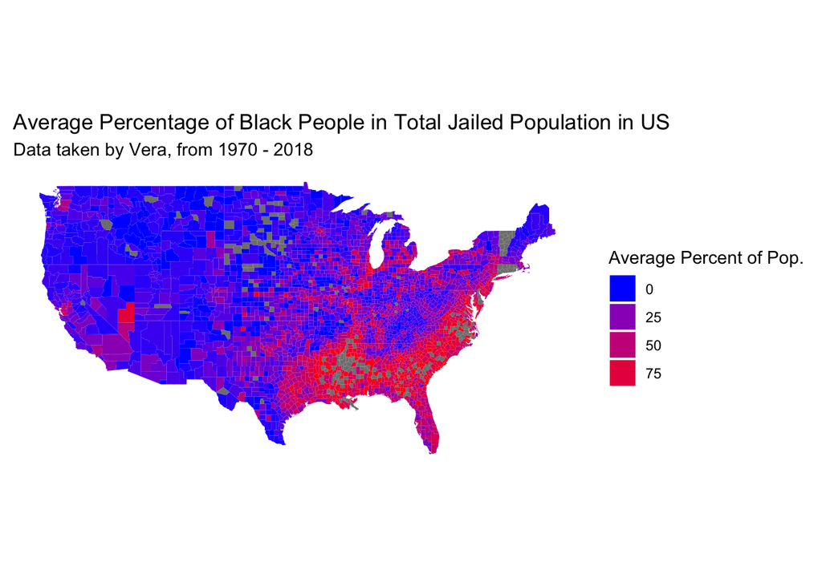

## Conclusion

We can conclude that with the data gathered, manipulated, and visualized that although all minorities show a disproportionate incarceration population percentage, the black population suffers it the most, with this single consistent trend showcasing in all 50 years of data being collected. With this data, we can try to make a change, reforming police forces, upholding communities, and ending the systemic racial prejudice that has been present towards the black population for all this time. If the power of data cannot convince one to help make a change, or convince those in power to do so- we are too far gone.